# The illusion of predictability in common scientific visualizations, faculty

2023-05-20

# 1 Loading data

We have four datasets: * `-tidy-background.csv` contains the background information for each participant. * `-tidy-psup-game.csv` contains information on each trial of the psup game. * `-tidy-editorial.csv` contains the last trial for which we have data on each participant, and the corresponding editorial data thus far * `-tidy-elapsed.csv` contains the timing data for each stage and trial

## 1.1 Background questions

We drop people who do not answer yes to any of the background questions or meet the other inclusion criteria. How many people would we drop?

```r
background_data <- read_faculty_bg()
```

How comfortable are the participants with statistics and data analysis?

```r
bg.field <- background_data %>%
  mutate(departmentField=recode_factor(departmentField,
                                       business="Business",
                                       computerscience="CS",
                                       lifescience="Life sciences",
                                       other="Other",
                                       physicalscience="Physical sciences",
                                       socialscience="Social sciences",
                                       statistics="Math/statistics")) %>%
  filter(departmentField != "") %>%
  ggplot(aes(x=departmentField)) +
    geom_bar() +
    theme(axis.text.x = element_text(angle=30, hjust=1)) +
    xlab("Field")



bg.comfort.with.stats <- background_data %>%
  ggplot(aes(x=comfortWithStats)) +
    geom_bar() +
    coord_cartesian(xlim = c(0.5, 5.5)) +
    xlab("Comfort with statistics")

bg.comfort.with.data <- background_data %>%
  ggplot(aes(x=comfortWithData)) +
    geom_bar() +
    coord_cartesian(xlim = c(0.5, 5.5)) +
    xlab("Comfort with data analysis")

background_data %>% group_by(papersReviewed) %>%
  summarise(count=n())
```

```
## # A tibble: 7 × 2
##   papersReviewed count
##   <chr>          <int>
## 1 ""               271
## 2 "0"                1
## 3 "1-10"            11
## 4 "100+"           146
## 5 "11-20"           19
## 6 "21-50"           51
## 7 "51-100"          67
```

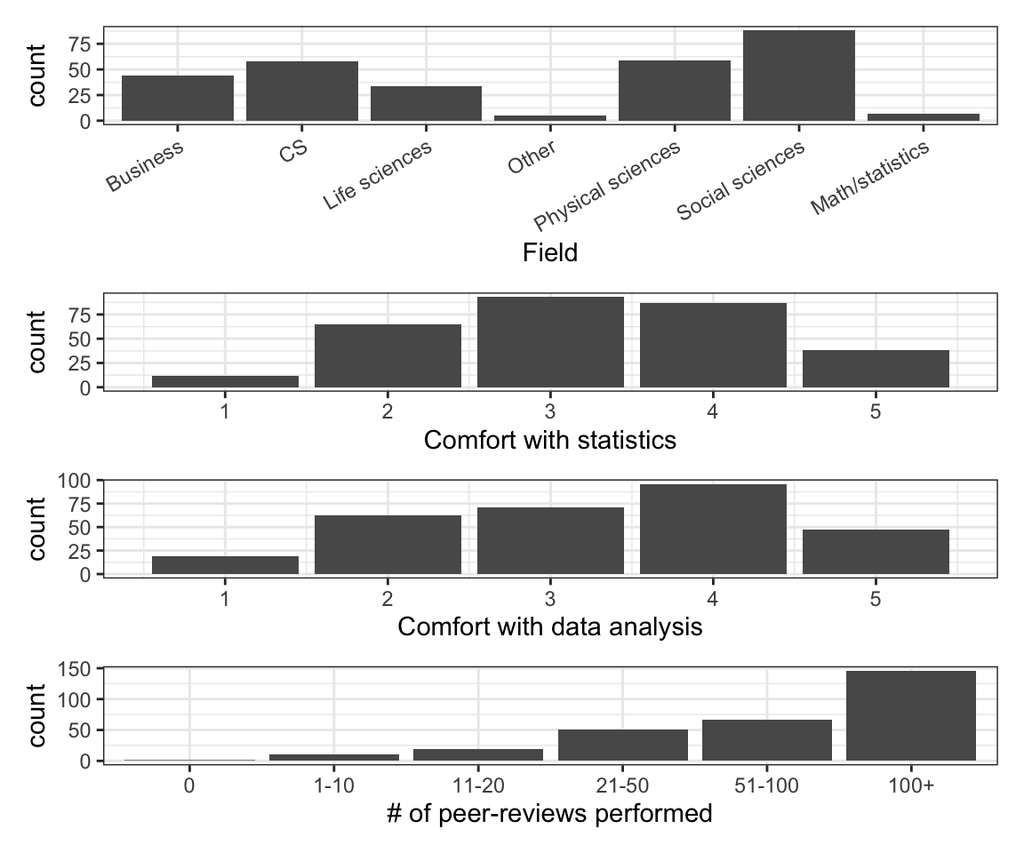

```r
bg.num.peer.reviews <- background_data %>%
  filter(papersReviewed != "") %>%
  mutate(papersReviewed = recode_factor(papersReviewed, "0"="0", "1-10"="1-10", "11-20"="11-20", "21-50"="21-50", "51-100"="51-100", "100+"="100+")) %>%
  ggplot(aes(x=papersReviewed)) +
    geom_bar() +
    xlab("# of peer-reviews performed")

bg.field / bg.comfort.with.stats / bg.comfort.with.data / bg.num.peer.reviews
```

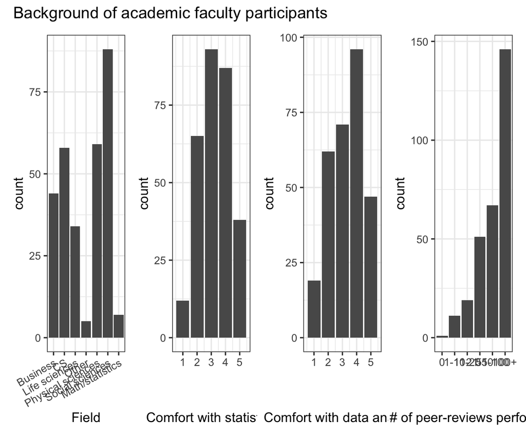

```r
ggsave(paste("figures/", faculty_experiment, "_background.pdf", sep=""), width=4, height=8)
bg.field + bg.comfort.with.stats + bg.comfort.with.data + bg.num.peer.reviews +
  plot_annotation(title = "Background of academic faculty participants") +
   plot_layout(nrow = 1)
```

```r
ggsave(paste("figures/", faculty_experiment, "_background_wide.pdf", sep=""), width=12, height=4)
table(background_data$taughtStats)
```

```
##
##      No Yes
## 271 200  95
```

```r
c(nrow(background_data %>% filter(isTenureTrackFaculty == "no")),
nrow(background_data %>% filter(comfortWithStats == 1)),
nrow(background_data %>% filter(comfortWithData == 1)),
nrow(background_data %>% filter(papersReviewed == 0)))
```

```
## [1] 46 12 19  1
```

```r
assignments_to_drop = background_data %>%
  filter((isTenureTrackFaculty == "no") | (comfortWithStats == 1) | (comfortWithData == 1) | (papersReviewed == 0)) %>%
  select(assignmentId)

faculty_assignments_dropped <- nrow(assignments_to_drop)

assignments_to_drop
```

```
##                            assignmentId
## 1  05c5724d-2da8-41d5-8e1a-c1c1d568437a
## 2  0646f605-2429-43c9-a205-04302b63fef2
## 3  11781a51-e597-4f96-a6ca-3789e1813e5c
## 4  150b3d26-8693-455f-87d3-d385f9f9bfe8
## 5  1513baa1-0914-47b2-bd91-0db9cd836ee2
## 6  16f9b817-04b3-4c21-9cf9-248171c77b5e
## 7  1807bd5f-affb-4147-98c6-92dac2251f7d
## 8  1fee8ceb-579d-44dd-857f-22003dc1510e
## 9  227de5ad-e747-4e44-8aba-898271333e27
## 10 22e86ca6-0db8-4809-9243-86e6061af812
## 11 23816378-f8a2-4af7-b75d-e91dc1413c0b
## 12 2701b9bf-de4f-4d71-b6eb-6eba1fb3152d
## 13 2ac2f5f3-9957-4c37-98b2-65c2c31ae1ec
## 14 2ced24df-7db6-42c0-8688-b6a11a723d84
```

[output cut: 49 more lines]

```r
table(background_data$departmentField)
```

```
##
##                        business computerscience     lifescience           other
##             271              44              58              34               5
## physicalscience   socialscience      statistics
##              59              88               7
```

## 1.2 Trial and editorial data

### 1.2.1 Statistical tests

```r
attach(read_faculty_data(background_data))
faculty_editorial_test_results <- editorial_tests(faculty_editorial_data)
attach(faculty_editorial_test_results)

faculty_editorial_test_results
```

```
## $appeal_t_stats
## [1] "t(356.3) = 0.324, p = .746"
##
## $overall_t_stats
## [1] "t(362.6) = 1.54, p = .124"
##
## $sample_t_stats
## [1] "t(349.2) = 1.58, p = .115"
##
## $paper_psup_extreme_t_stats
## [1] "t(363) = 2.6, p = .010"
##
## $paper_psup_extreme_props
## # A tibble: 2 × 3
##   condition   num_extreme prop_extreme
##   <fct>             <int>        <dbl>
## 1 SE Only              42        0.211
## 2 SE + Points          19        0.112
##
## $paper_psup_t_stats
## [1] "t(363.9) = 4.52, p < .001"
##
## $editorial_psup_summaries
## # A tibble: 2 × 3
##   condition      mu    sd
##   <fct>       <dbl> <dbl>
## 1 SE Only      68.3  18.8
## 2 SE + Points  60.4  14.8
```

### 1.2.2 Editorial judgments

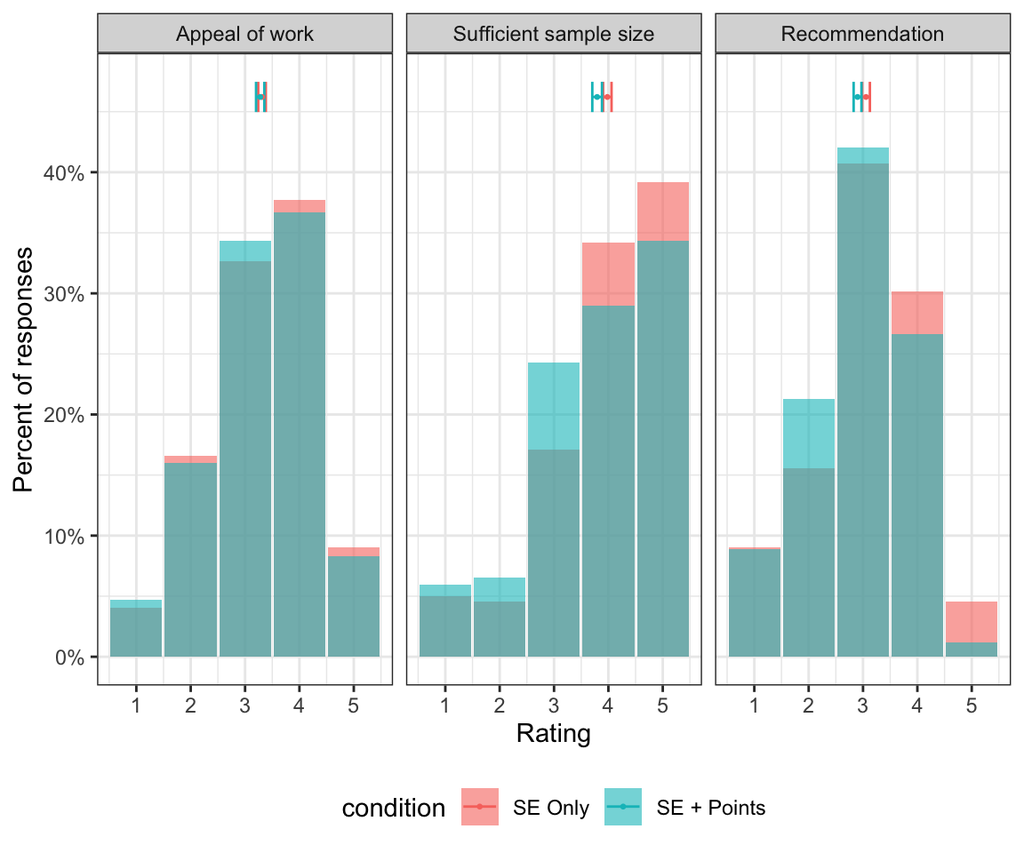

```r
editorial_plot <- plot_editorial_data(faculty_editorial_data)
editorial_plot
```

```r
ggsave(paste("figures/", faculty_experiment, "_editorial_responses_histograms_overlayed.pdf", sep=""), width=7, height=3)
```

### 1.2.3 Probability of superiority judgment for paper

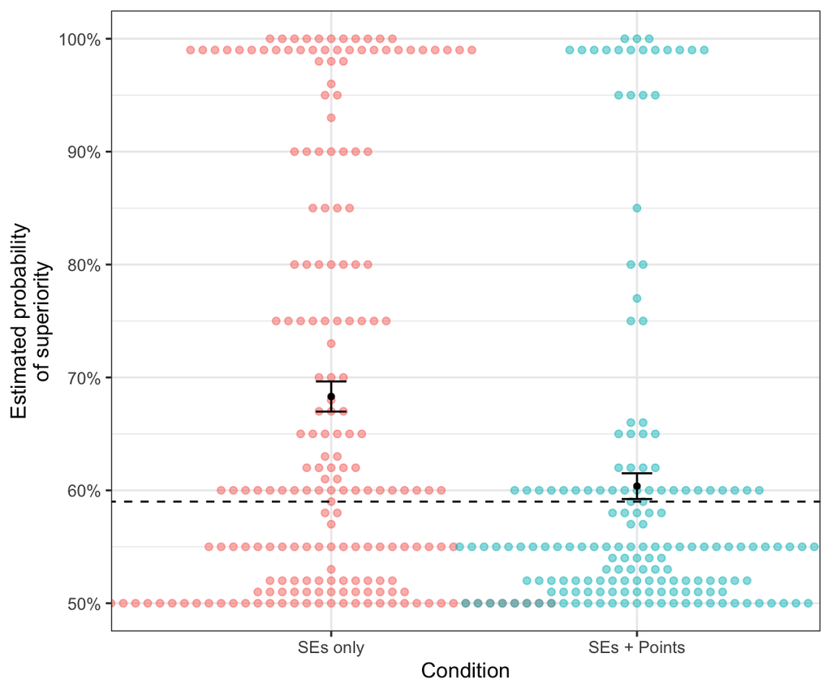

```r
editorial_psup_figure <- plot_editorial_psup(faculty_editorial_data)
editorial_psup_figure
```

```r
ggsave(paste("./figures/", faculty_experiment, "_estimated_psup.pdf", sep=""), width=4, height=4)
```

### 1.2.4 Perceived error bars

What did people think they saw?

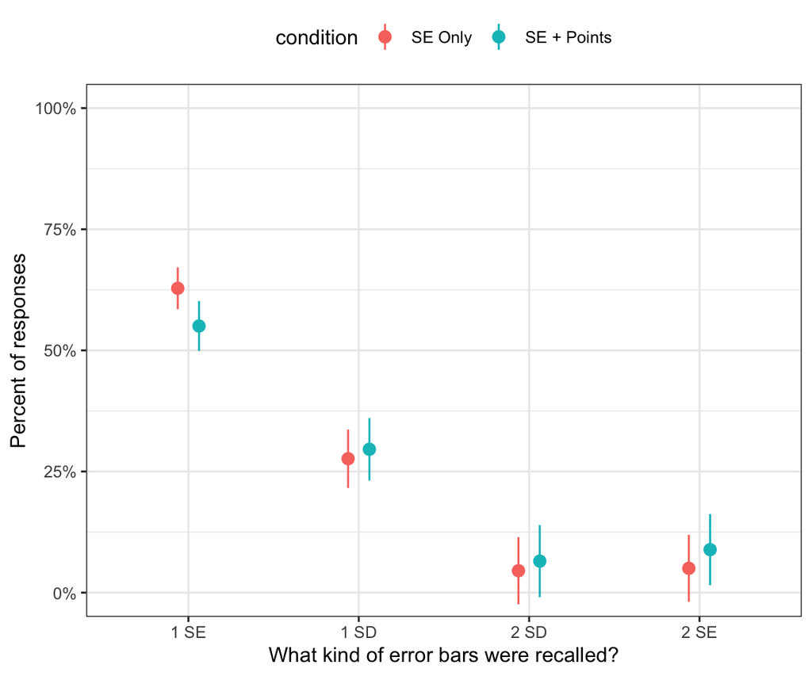

```r
plot_whatYouSaw_q1(faculty_editorial_data)
```

```r
ggsave(paste("./figures/", faculty_experiment, "_recalled_q1.pdf", sep=""), width=4, height=4)
```

```r
faculty_recalled_test_results_q1 <- recalled_tests_q1(faculty_editorial_data)
attach(faculty_recalled_test_results_q1)

faculty_recalled_q1 <- faculty_recalled_test_results_q1$whatYouSaw %>% filter(paperA_whatYouSaw == "1 SE")
faculty_recalled_q1_SEvsSD <- faculty_recalled_test_results_q1$whatYouSaw_SEvsSD %>% filter(whatYouSaw == "SE")

faculty_recalled_test_results_q1
```

```
## $whatYouSaw
## # A tibble: 8 × 5
## # Groups:   condition [2]
##   condition   paperA_whatYouSaw     n   frac     se
##   <fct>       <fct>             <int>  <dbl>  <dbl>
## 1 SE Only     1 SD                 55 0.276  0.0603
## 2 SE Only     1 SE                125 0.628  0.0432
## 3 SE Only     2 SD                  9 0.0452 0.0693
## 4 SE Only     2 SE                 10 0.0503 0.0691
## 5 SE + Points 1 SD                 50 0.296  0.0645
## 6 SE + Points 1 SE                 93 0.550  0.0516
## 7 SE + Points 2 SD                 11 0.0651 0.0744
## 8 SE + Points 2 SE                 15 0.0888 0.0734
##
## $whatYouSaw_SEvsSD
## # A tibble: 4 × 5
## # Groups:   condition [2]
##   condition   whatYouSaw     n  frac     se
##   <fct>       <fct>      <int> <dbl>  <dbl>
## 1 SE Only     SD            64 0.322 0.0584
## 2 SE Only     SE           135 0.678 0.0402
## 3 SE + Points SD            61 0.361 0.0615
## 4 SE + Points SE           108 0.639 0.0462
```

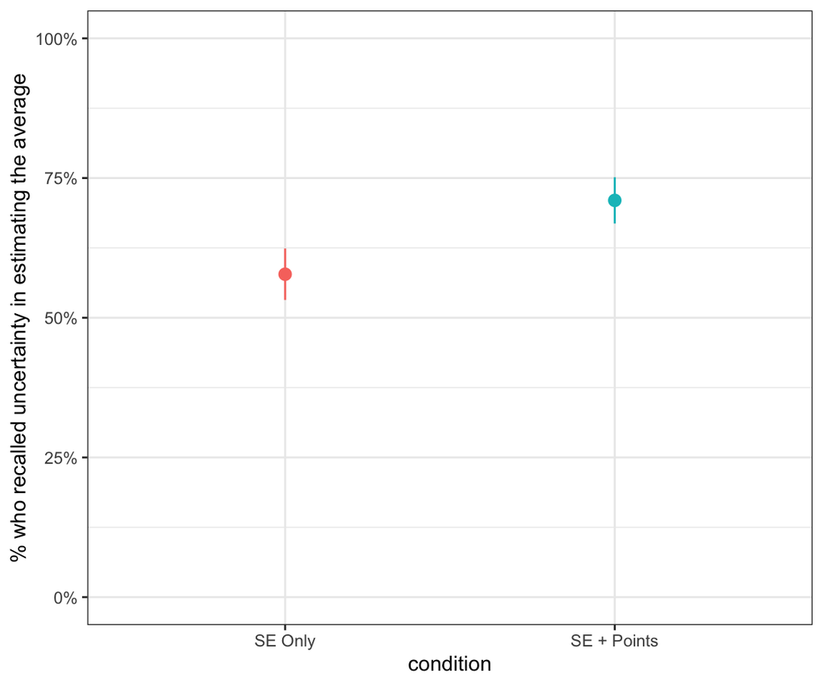

```r
plot_whatYouSaw_q2(faculty_editorial_data)
```

```r
ggsave(paste("./figures/", faculty_experiment, "_recalled_q2.pdf", sep=""), width=4, height=4)

faculty_recalled_test_results <- recalled_tests(faculty_editorial_data)
attach(faculty_recalled_test_results)

faculty_recalled_test_results
```

```
## $recalled_avg_means
## # A tibble: 2 × 5
## # Groups:   condition [2]
##   condition   paperA_whatYouSaw2      n  frac     se
##   <fct>       <chr>               <int> <dbl>  <dbl>
## 1 SE Only     recalled_uncert_avg   115 0.578 0.0461
## 2 SE + Points recalled_uncert_avg   120 0.710 0.0414
##
## $recalled_avg_t_stats
## [1] "t(363.7) = -2.67, p = .008"
```

### 1.2.5 Mediation of overall effect by perceived error bars

If we include the error bars as a covariate, can we explain the main effect of condition on the perceived probability of superiority?

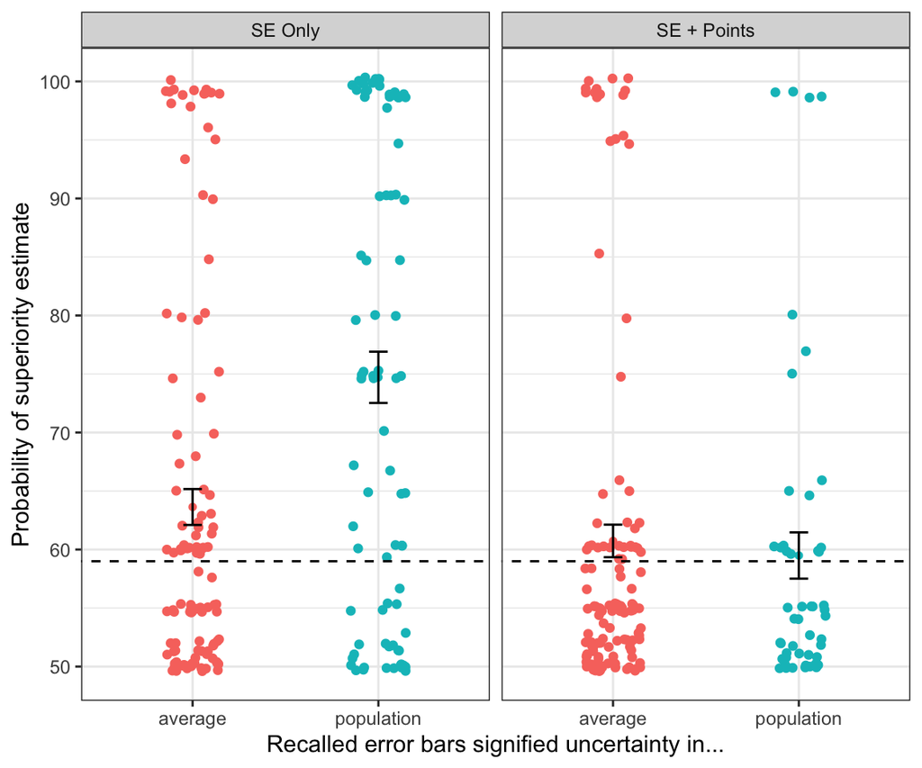

```r
plot_accuracy_vs_recalled(faculty_editorial_data)
```

```r
ggsave(paste("./figures/", faculty_experiment, "_recalled_q2_vs_psup.pdf", sep=""), width=6, height=4)
```

```r
paper_psup_fac <- faculty_editorial_data %>% filter(!is.na(paperA_superiorityEstimate))
mod.supestimate.mediation <- lm(paperA_superiorityEstimate ~ relevel(as.factor(paperA_whatYouSaw2), ref="recalled_uncert_pop") + condition, paper_psup_fac)
summary(mod.supestimate.mediation)
```

```
##
## Call:
## lm(formula = paperA_superiorityEstimate ~ relevel(as.factor(paperA_whatYouSaw2),
##     ref = "recalled_uncert_pop") + condition, data = paper_psup_fac)
##
## Residuals:
##     Min      1Q  Median      3Q     Max
## -21.741 -11.741  -5.652   4.193  41.348
##
## Coefficients:
##                                                                                        Estimate
## (Intercept)                                                                              71.741
## relevel(as.factor(paperA_whatYouSaw2), ref = "recalled_uncert_pop")recalled_uncert_avg   -5.935
## conditionSE + Points                                                                     -7.154
##                                                                                        Std. Error
## (Intercept)                                                                                 1.606
## relevel(as.factor(paperA_whatYouSaw2), ref = "recalled_uncert_pop")recalled_uncert_avg      1.851
## conditionSE + Points                                                                        1.785
##                                                                                        t value
## (Intercept)                                                                             44.669
## relevel(as.factor(paperA_whatYouSaw2), ref = "recalled_uncert_pop")recalled_uncert_avg  -3.206
## conditionSE + Points                                                                    -4.009
##                                                                                        Pr(>|t|)
## (Intercept)                                                                             < 2e-16
## relevel(as.factor(paperA_whatYouSaw2), ref = "recalled_uncert_pop")recalled_uncert_avg  0.00147
## conditionSE + Points                                                                   7.39e-05
##
## (Intercept)                                                                            ***
## relevel(as.factor(paperA_whatYouSaw2), ref = "recalled_uncert_pop")recalled_uncert_avg **
## conditionSE + Points                                                                   ***
## ---
## Signif. codes:  0 '***' 0.001 '**' 0.01 '*' 0.05 '.' 0.1 ' ' 1
##
## Residual standard error: 16.9 on 365 degrees of freedom
## Multiple R-squared:  0.07699,    Adjusted R-squared:  0.07194
## F-statistic: 15.22 on 2 and 365 DF,  p-value: 4.465e-07
```

Mediation of editorial judgment by perceived psup

```r
mod.editorial.mediation <- lm(q_overall ~ paperA_superiorityEstimate + condition, paper_psup_fac)
summary(mod.editorial.mediation)
```

```
##
## Call:
## lm(formula = q_overall ~ paperA_superiorityEstimate + condition,
##     data = paper_psup_fac)
##
## Residuals:
##     Min      1Q  Median      3Q     Max
## -2.4417 -0.7729  0.1427  0.8022  2.1783
##
## Coefficients:
##                             Estimate Std. Error t value Pr(>|t|)
## (Intercept)                 2.222221   0.209469  10.609  < 2e-16 ***
## paperA_superiorityEstimate  0.012195   0.002903   4.200 3.36e-05 ***
## conditionSE + Points       -0.059055   0.102062  -0.579    0.563
## ---
## Signif. codes:  0 '***' 0.001 '**' 0.01 '*' 0.05 '.' 0.1 ' ' 1
##
## Residual standard error: 0.9505 on 365 degrees of freedom
## Multiple R-squared:  0.05219,    Adjusted R-squared:  0.047
## F-statistic: 10.05 on 2 and 365 DF,  p-value: 5.642e-05
```

```r
mod.editorial.mediation.bg <- fit_psup_vs_overall_emm_faculty(background_data, faculty_editorial_data)
fac_mediation_psup_coef <- tidy(coeftest(mod.editorial.mediation.bg, vcov. = vcovCL, cluster=~departmentField)) %>%
  filter(term == "paperA_superiorityEstimate")
fac_mediation_psup_coef
```

```
## # A tibble: 1 × 5
##   term                       estimate std.error statistic   p.value
##   <chr>                         <dbl>     <dbl>     <dbl>     <dbl>
## 1 paperA_superiorityEstimate   0.0132   0.00308      4.29 0.0000242
```

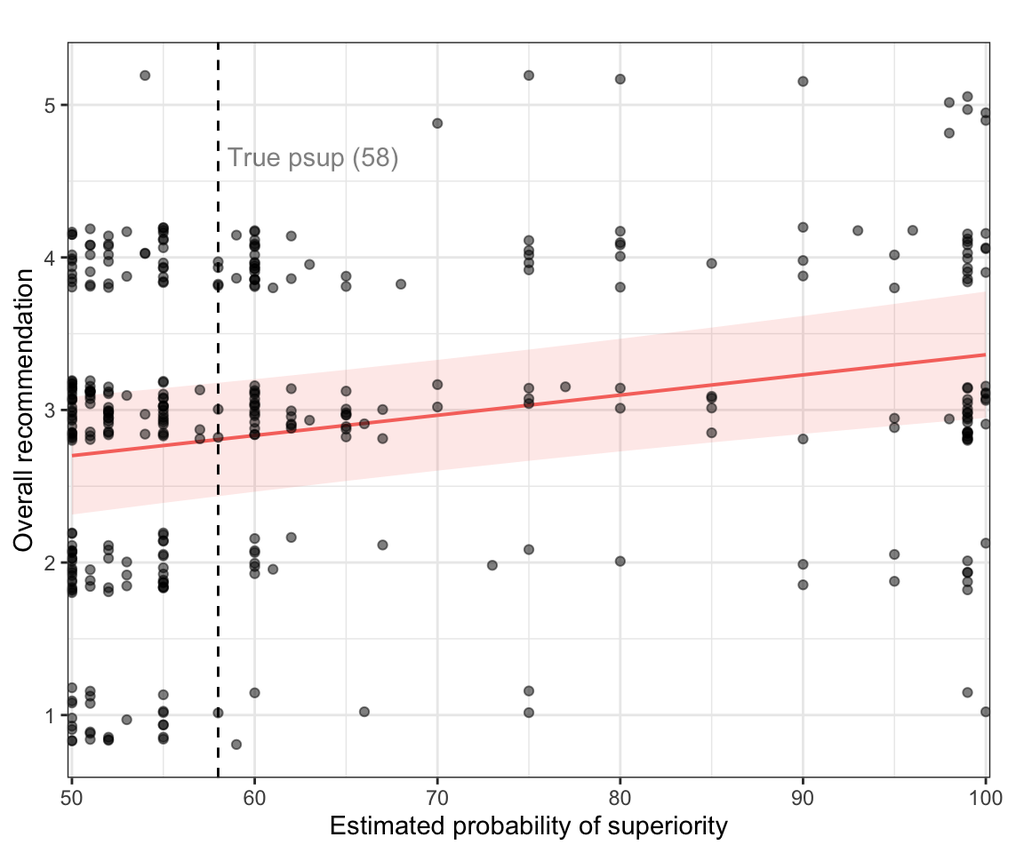

```r
plot_psup_vs_overall_emm(mod.editorial.mediation.bg, faculty_editorial_data) +
  geom_vline(xintercept=58, linetype="dashed") +
  geom_text(data=data.frame(x=58.5, y=4.6, text="True psup (58)"), aes(x=x,y=y,label=text), alpha=0.5, hjust="left", vjust="bottom")
```

```r
ggsave(paste("./figures/", faculty_experiment, "_psup_vs_editorial.pdf", sep=""), width=4, height=4)
```

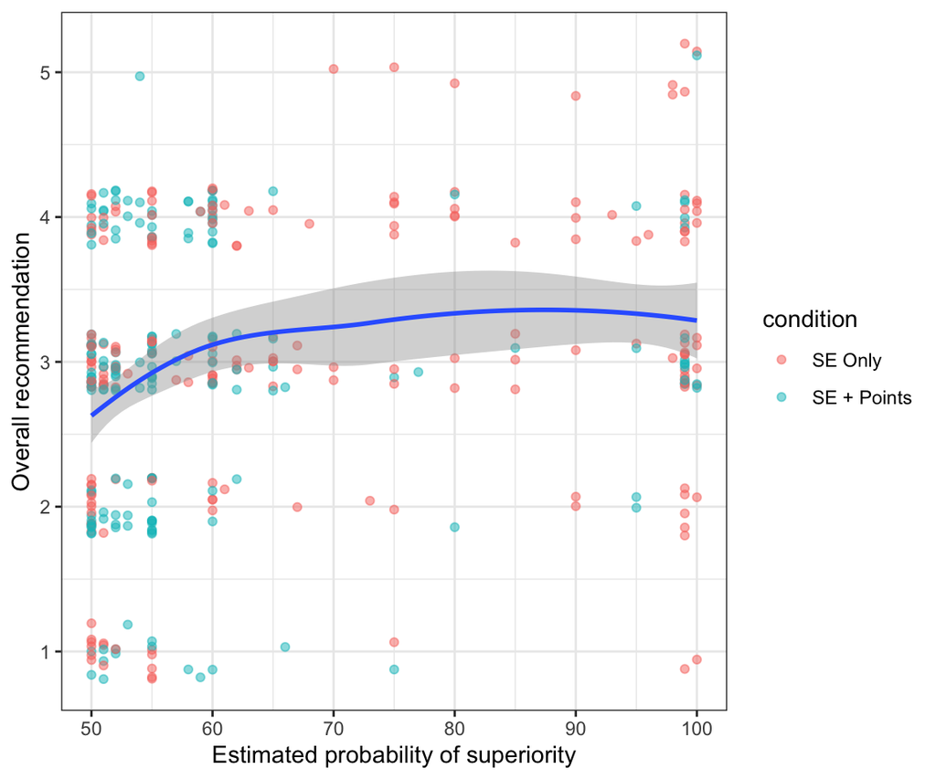

```r
ggplot(paper_psup_fac, aes(x=paperA_superiorityEstimate, y=q_overall)) +
  geom_jitter(aes(color=condition), width=0, height=0.2, alpha=0.5) +
  geom_smooth() +
  labs(x="Estimated probability of superiority", y="Overall recommendation")
```

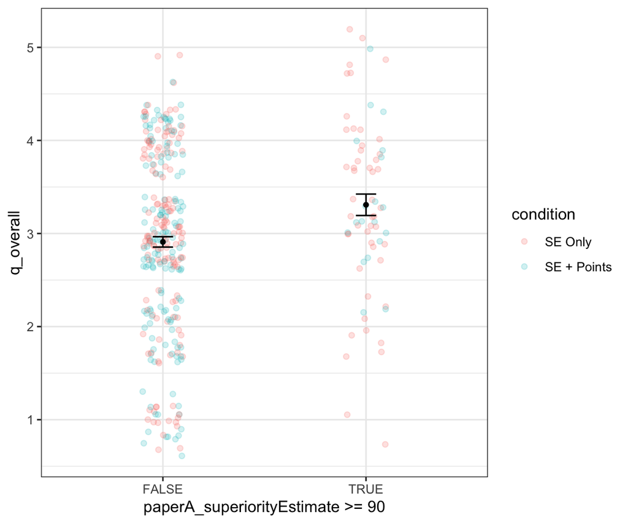

```r
ggplot(paper_psup_fac, aes(x=paperA_superiorityEstimate >= 90, y=q_overall)) +
  geom_jitter(aes(color=condition), width=0.1, alpha=0.2) +
  #geom_smooth() +
  stat_summary(fun = mean, geom = "point", size=1.2) +
  stat_summary(fun.data="mean_se",  fun.args = list(mult=1),
               geom="errorbar", color = "black", width=0.1)
```

```r
  #geom_smooth(method='lm')
```

Do people from some field give more accurate estimates than others?

```r
paper_psup_fac_bg <- merge(
  background_data %>% filter(departmentField != "") %>% select(-c(condition)),
  paper_psup_fac,
  by="assignmentId"
)

# 58 is the correct answer: look at absolute errors
mod.est.by.field <- lm(abs(paperA_superiorityEstimate - 58) ~ condition + relevel(as.factor(departmentField), ref=7), paper_psup_fac_bg)
summary(mod.est.by.field)
```

```
##
## Call:
## lm(formula = abs(paperA_superiorityEstimate - 58) ~ condition +
##     relevel(as.factor(departmentField), ref = 7), data = paper_psup_fac_bg)
##
## Residuals:
##     Min      1Q  Median      3Q     Max
## -17.592  -8.540  -3.540   1.854  33.820
##
## Coefficients:
##                                                             Estimate Std. Error
## (Intercept)                                                  10.3963     4.9759
## conditionSE + Points                                         -6.1935     1.5269
## relevel(as.factor(departmentField), ref = 7)business          7.1961     5.2761
## relevel(as.factor(departmentField), ref = 7)computerscience   2.9769     5.1916
## relevel(as.factor(departmentField), ref = 7)lifescience      10.0069     5.3851
## relevel(as.factor(departmentField), ref = 7)other             3.0424     7.6104
## relevel(as.factor(departmentField), ref = 7)physicalscience   0.9432     5.1852
## relevel(as.factor(departmentField), ref = 7)socialscience     5.1440     5.0937
##                                                             t value Pr(>|t|)
## (Intercept)                                                   2.089   0.0376
## conditionSE + Points                                         -4.056 6.43e-05
## relevel(as.factor(departmentField), ref = 7)business          1.364   0.1737
## relevel(as.factor(departmentField), ref = 7)computerscience   0.573   0.5668
## relevel(as.factor(departmentField), ref = 7)lifescience       1.858   0.0642
## relevel(as.factor(departmentField), ref = 7)other             0.400   0.6896
## relevel(as.factor(departmentField), ref = 7)physicalscience   0.182   0.8558
## relevel(as.factor(departmentField), ref = 7)socialscience     1.010   0.3134
##
## (Intercept)                                                 *
## conditionSE + Points                                        ***
## relevel(as.factor(departmentField), ref = 7)business
## relevel(as.factor(departmentField), ref = 7)computerscience
## relevel(as.factor(departmentField), ref = 7)lifescience     .
## relevel(as.factor(departmentField), ref = 7)other
## relevel(as.factor(departmentField), ref = 7)physicalscience
## relevel(as.factor(departmentField), ref = 7)socialscience
## ---
## Signif. codes:  0 '***' 0.001 '**' 0.01 '*' 0.05 '.' 0.1 ' ' 1
##
## Residual standard error: 12.96 on 287 degrees of freedom
## Multiple R-squared:  0.09758,    Adjusted R-squared:  0.07557
## F-statistic: 4.433 on 7 and 287 DF,  p-value: 0.0001068
```

# 2 Part II: Analyses of the psup game

## 2.1 True psup vs. signed error

This is Part II of the experiment, and here we are examining how the guessed probability of superiority varies based on the true probability of superiority.

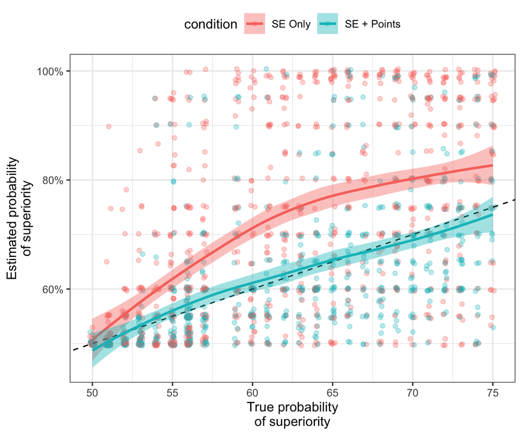

```r
plot_psup_game(faculty_trials)
```

```r
ggsave(paste("./figures/", faculty_experiment, "_psup_game.pdf", sep=""), width=4, height=4)
faculty_psup_game_tests <- psup_game_tests(faculty_trials)
attach(faculty_psup_game_tests)

faculty_psup_game_tests
```

```
## $trials_lmer_coef
## # A tibble: 1 × 4
##   term                           estimate std.error statistic
##   <chr>                             <dbl>     <dbl>     <dbl>
## 1 conditionSE_POINTS_NO_FEEDBACK    -5.88     0.888     -6.63
##
## $trials_extreme_means
## # A tibble: 2 × 4
##   condition             num_extreme prop_extreme count
##   <chr>                       <int>        <dbl> <int>
## 1 SE_NO_FEEDBACK                182       0.215    845
## 2 SE_POINTS_NO_FEEDBACK          36       0.0541   665
##
## $trials_extreme_t_stats
## [1] "$t(1362.4) = 9.68$, $p < .001$"
```

# 3 Saving output in .Rdata for .Rtex document

```r
save(
  faculty_assignments_dropped,
  appeal_t_stats, overall_t_stats, sample_t_stats,
  editorial_psup_summaries, paper_psup_t_stats, paper_psup_extreme_props, paper_psup_extreme_t_stats,
  faculty_recalled_q1, faculty_recalled_q1_SEvsSD, recalled_avg_means, recalled_avg_t_stats,
  trials_lmer_coef, trials_extreme_means, trials_extreme_t_stats,
  fac_mediation_psup_coef,
  file=paste("results/", faculty_experiment, "_results.Rdata", sep=""))
```

# 4 Part III: Free response feedback

```r
show_feedback(faculty_experiment)
```

| condition | feedback |
| --- | --- |
| SE_POINTS_NO_FEEDBACK | I found it more challenging than expected since my discipline deals w/ much larger N studies in which scatterplots or graphs showing individual data points are rarely informative. Good luck w/ your pr… |
| SE_POINTS_NO_FEEDBACK | Interesting exercise! |
| SE_NO_FEEDBACK | It's profoundly stoopid to estimate these probabilities; they are not what is at stake in hypothesis testing. If one wants to know those probabilities, one can write code to calculate them from normal… |
| SE_NO_FEEDBACK | Cool study and I like the "reward" for participation! |
| SE_NO_FEEDBACK | Ok, I've reviewed lots of papers, but never an experiment (or even group differences with small Ns). So these were all wild guesses. |
| SE_NO_FEEDBACK | It took me a few goes to recognize your jargon. What you were calling standard error, I *think* was what I know as the standard error of the mean which is roughly the sd/sqrt(N). After I caught on tha… |
| SE_NO_FEEDBACK | In my field of physics, all data points are plotted with +- 1 standard deviation on them. Also the only thing we call the "error" on a set of data points is in fact the 1 sigma standard deviation. On … |
| SE_NO_FEEDBACK | This was a difficult and tricky test with the choices and guessing we had to do! The "P" values are for the probability of a type I error for the null hypothesis of no difference between the two group… |
| SE_POINTS_NO_FEEDBACK | I am reasonably comfortable with interpreting inferential statistics but I have not generally used plots of errors rather than probability estimates. My research for the last decade or so has been the… |
| SE_NO_FEEDBACK | The questions (not the study) got me to think about the relative sizes of random fluctuations and the 'effect' measured, but it focussed my attention on the fact that I had no clean criterion for comp… |

[output cut: 81 more lines]